# Transformation & Sustainability

AI and the future of work, AI and the limits of the planet

Author

Affiliation

Prof. Dr. Markus Oermann

THWS FIW

Published

September 11, 2026

[figure not shown]

In the previous unit we watched AI reshape the digital public sphere, flooding it with synthetic content and straining the conditions of honest discourse. This unit widens the lens from what AI does *to information* to what it does *to society and to the planet*, asking whether the current AI wave is a genuine transformation of how we work, and at what ecological cost it arrives. We proceed in two parts: first the transformation of work, read through modernization theory and its critics, then the sustainability of AI itself, read through the water and carbon it consumes and the rebound effects it triggers.

## 1 AI and the transformation of work

### 1.1 Transition, transformation and the language of revolution

It helps to fix a distinction at the outset. A **transition** is change *within* given structures, while a **transformation** is a change *of* the structures themselves. Rearranging a factory floor is a transition; the arrival of the factory as such was a transformation. History offers a familiar catalogue of the latter: urbanization, industrialization, the collapse of the Eastern Bloc between 1989 and 1991, and, in our own moment, the twin ongoing transformations that the European Union has made into policy goals, the green transformation toward climate neutrality by 2050 and the open-ended digital transformation. Everyday language tends to inflate such deep shifts into “revolutions”, and the question hanging over this unit is whether the AI wave, and generative AI in particular, deserves that word.

#### Transition vs. transformation

A transition is change within existing structures; a transformation is a change of the structures themselves. Big transformations are what everyday language calls “revolutions”.

### 1.2 Modernization theory: how societies transformed

To judge whether AI is transformative, it helps to have a theory of what made earlier transformations tick. Modernization theory asks how Western societies changed so rapidly and so deeply across the eighteenth, nineteenth and twentieth centuries, and its striking answer is that the causes were not external shocks but a bundle of *internal*, mutually reinforcing trends. The first is **functional differentiation**: the subsystems of society, law, politics, the economy, religion, grow more independent and each develops its own operating logic, which proves more efficient than traditional societies dominated by a single sphere. The second is **mobilization**: individuals, groups and resources such as capital, labour, knowledge and technology become mobile both geographically and across social hierarchies, while the market rises to become the dominant mechanism of distribution. Alongside these run technical and cultural innovation, urbanization and industrialization, and a collective leap in welfare that reshapes institutions, giving us modern universities, healthcare and social-security systems, with equality emerging as a core value.

The third strand concerns **participation and conflict resolution**. As the traditional legitimation of decisions by authority is called into question, societies build institutionalized mechanisms to mediate between their differentiated spheres: parliamentary and party democracy, trade unions and employer associations. In parallel the modern concept of the **citizen** takes shape, defined by equality before the law, a claim to a say in public policy through voting and free opinion, and a right to self-determination in education, work and family life. Read together, these strands describe not a single invention but a self-propelling structural shift, which is exactly the template against which any candidate “AI revolution” must be measured.

Which pair best captures the core mechanisms of classical modernization theory?

- External conquest and religious unification
- **Functional differentiation and mobilization, with market distribution and expanding participation**
- Central planning and de-industrialization
- Stagnation and the return to traditional authority

### 1.3 The critiques: alienation, postcolonial extraction, ecological limits

Modernization was never a neutral success story, and four critiques matter for how we read AI. Marxist **historical materialism** argues that the modern subject, and above all the working class, becomes increasingly *alienated* (*entfremdet*) under the exploitative structures of capitalism, estranged from the product and the process of its own labour. **Critical Theory** adds that modernization brings a relentless acceleration that disrupts social ties and uproots people; Hartmut Rosa’s diagnosis of the late-modern “society of acceleration” (2005) sharpens this point, since technical speed-up promises time yet empirically produces time scarcity, because the pace of life rises in step with efficiency, and digital technologies intensify all of it. The **postcolonial critique** insists that the modernization of the global North was enabled by slavery and the exploitation of colonies in the global South, and that those asymmetric power structures remain in force. The **ecological critique**, finally, points to the ongoing over-use of natural resources and the destruction of the biosphere on which modern growth rests. Each of these will return, unbidden, when we look at how AI transforms work and what it costs the planet.

The claim that the worker is estranged from the product of their labour is the charge of *alienation*; the claim that the North’s prosperity rests on exploitation of the South is the *postcolonial* critique; the claim that growth over-uses nature is the *ecological* critique.

### 1.4 Is AI transformative? White-collar work in the frame

Earlier waves of mechanization hit primarily **blue-collar** jobs. There were indeed mass layoffs in simple manual work, but new professions also arose, demanding different skills and educational profiles. The recurring claim about the current, AI-driven phase is that it will strike primarily **white-collar** office work, reaching the cognitive tasks that earlier automation left untouched. The empirical picture, however, resists both hype and panic. A literature review by Baudchon and Huynh (2025) frames the field around an **evidence paradox**: microeconometric studies routinely find sizeable productivity gains from AI, yet at the macro level those gains are so far barely visible in aggregate growth, echoing the older “productivity paradox” of information technology, which spread from the 1970s but showed up in the statistics only in the 1990s.

Two paradigms structure the debate. The **substitution** view, associated with Acemoglu, distinguishes automation technologies that *replace* tasks from technologies that *reinstate* tasks in new fields, and warns that current AI investment leans heavily toward replacement without an equivalent creation effect, risking structural job loss. The **complementarity** view, associated with Brynjolfsson, holds that AI augments human work, raises productivity and opens new fields, with human-plus-AI “centaur” configurations outperforming either alone, and invokes the *lump-of-labour* fallacy, the observation that technological change has historically created new work despite painful transitions. The task-based literature refines this into a polarization thesis: routine cognitive and manual tasks are most automatable, hollowing out the middle, while high-skill analytical work is complemented and low-skill non-routine manual work resists automation. Generative AI complicates the old story, because it now exposes analytical knowledge work, drafting contracts, code and text, that used to sit safely at the top. As we will see, the first payroll evidence complicates it further, since the sharpest line in the data runs not across skill levels at all but along seniority.

The automation-versus-augmentation split is easier to grasp per occupation than in the aggregate. The explorer below lets you pick a job, see how its tasks divide between outright automation, human-in-the-loop augmentation and little exposure, and read the mix through the substitution and complementarity paradigms.

[interactive chart not shown]

### 1.5 The first empirical signals: canaries in the coal mine

Until recently the two paradigms were argued largely a priori, with each side pointing to plausible mechanisms and to history. That is changing. Brynjolfsson, Chandar and Chen (2026) track administrative payroll records from the provider ADP covering millions of US workers, with data through June 2026, and report six descriptive facts. The first is reassuring: there is **no evidence of widespread, economy-wide job displacement**, which fits the evidence paradox we have just met. The second is not: employment of workers aged 22 to 25 in the most AI-exposed occupations stands **19 percent below where it would be had it kept pace with their less-exposed peers**, while experienced workers show no comparable gap. In plain levels, employment of 22 to 25-year-olds in the two most exposed quintiles fell by roughly 11 percent between November 2022 and June 2026, while the same age group in the three least exposed quintiles grew by about 10 percent. The third fact is that this divergence has widened steadily since the authors first documented it in August 2025, when the same measure stood at 15 percent.

Three further facts sharpen the picture. The gap operates **through reduced hiring rather than increased separations**, which means the displacement is largely invisible: it takes the form of positions that are never advertised rather than of people escorted out of the building. Second, the declines concentrate precisely where AI is used to **substitute** for human tasks; where usage is primarily **complementary**, employment is flat or rising, a distinction the authors draw from the automative and augmentative classification in the Anthropic Economic Index. Third, the adjustment shows up in employment rather than in base pay, so the labour market is clearing through headcount, not through wages. As a mechanism the authors suggest that generative AI substitutes best for **codified** knowledge, the kind formal education certifies, while complementing the **tacit**, experience-based knowledge that senior staff hold, which is exactly the knowledge that entry-level positions used to exist in order to build.

Read against the theory, three things follow. The relevant axis turns out to be the **career ladder rather than the skill ladder**: the polarization thesis predicts a hollowed-out middle, whereas the data show a narrowing entrance. The substitution and complementarity paradigms stop looking like rival prophecies and start looking like descriptions of two different *usage patterns* of the same technology, which is a strong empirical vindication of this unit’s recurring claim that outcomes are designed rather than fated. And it is worth noting who signs the paper: Erik Brynjolfsson, whom we met as the face of the complementarity view, is the lead author documenting the entry-level decline, which should immunize us against reading this debate as a contest between optimists and pessimists. The authors add one further heterogeneity that belongs to the distributional question: women work in more AI-exposed occupations than men at every age, and the declines for young women are correspondingly steeper.

#### The narrowing entrance

Where AI has affected employment so far, it has done so by suppressing hiring rather than by causing dismissals. The effect is therefore borne almost entirely by labour market entrants and is statistically invisible in separation and unemployment figures.

**Deep dive: how much weight can these numbers carry?**

A great deal turns on how this study is read, so the caveats matter as much as the findings, and the authors state them plainly. These are **descriptive facts, not causal estimates**: the paper documents a correlation between occupational AI exposure and entry-level employment, and it does not establish that generative AI caused it. The sample is drawn from firms that use ADP as their payroll provider, so **selection into the sample** cannot be ruled out, and the divergence is indeed more pronounced in this panel than in national survey benchmarks such as the Current Population Survey. The estimates **attenuate when controlling for the education level of an occupation**, which may mean either that education is the real driver or that education is precisely the channel through which AI operates, and the data cannot distinguish the two. There are also **pre-trends**: more- and less-exposed occupations already diverged somewhat around the COVID-19 pandemic, before ChatGPT existed. Finally, the compensation finding rests on **base salary only**, excluding bonuses, commissions and equity, which are largest in exactly the high-income occupations under study, so adjustment through pay could be occurring unobserved.

Against these concerns the authors set four counter-observations: the divergence has kept widening long after interest rates peaked, the gap has moved below its pre-pandemic baseline rather than back toward it, the declines load specifically on automating rather than complementary usage and show a clear age gradient that interest-rate or remote-work explanations do not predict, and US government administrative data show consistent raw patterns. The honest summary is therefore neither “AI is destroying entry-level work” nor “nothing is happening”, but that a signal has appeared which is consistent with the hypothesis and which is worth tracking. Treating a working paper of this kind as either proof or noise is the characteristic failure mode in this debate.

### 1.6 The quality of work, not just its quantity

Counting jobs is only half the ethical question. Even where employment survives, AI can change the *quality* of work, and Bankins and Formosa (2023) supply the framework. Work is meaningful along several dimensions, autonomy, task identity and significance, the use and development of competence, social embeddedness, and a sense of purpose, and AI threatens these along three paths. **Deskilling** occurs when AI absorbs the complex, developing parts of a job and leaves humans the residual, simpler tasks, producing the paradox that more advanced AI can create *simpler* jobs. **De-autonomization** occurs when algorithmic management dictates how, when and where work happens, draining the sense of agency. **Depersonalization** occurs when hiring, evaluation and even dismissal are mediated by systems, stripping work of its intersubjective recognition. The same technology can, in principle, remove tedious or dangerous tasks and augment human judgement, so **the outcome is a design choice rather than a technological fate, which is why the constructive answer points back to the value-driven, participatory design we met in earlier units.**

### 1.7 Ghost work: the human labour inside “automated” AI

The tidiest way to puncture the myth of fully automated AI is to look at who cleans its training data. Generative models rely heavily on human **data trainers** who label content and remove misinformation and harmful material, the hate, violence and abuse imagery that the model must learn *not* to reproduce. This labour is frequently outsourced to low-income countries under precarious conditions. The best-documented case involves workers in Kenya, sometimes called the “Silicon Savannah”, engaged through subcontractors to filter toxic content for OpenAI, reportedly for very low pay and with significant psychological toll from constant exposure to disturbing material. This “ghost work” makes the **postcolonial critique** of modernization suddenly concrete: the visible productivity of AI in the global North rests, in part, on invisible, poorly protected labour in the global South, an asymmetry the polished product is designed to hide.

**Deep dive: why ghost work is easy to overlook**

Ghost work is structurally invisible for three compounding reasons. First, it is *contractually distant*: the labour reaches the model developer through layers of subcontractors, so no single company appears to employ the workers directly, which also diffuses responsibility in the “many hands” sense we met earlier. Second, it is *geographically distant*, performed in jurisdictions with weaker labour protection and far from the users who benefit. Third, it is *rhetorically hidden*, because the marketing language of “automation” and “artificial intelligence” actively obscures the human effort inside the system. Naming the labour is therefore the first ethical step: an honest account of AI’s transformation of work has to include the jobs the technology *creates* at its own margins, not only the jobs it augments or replaces at the centre.

## 2 AI and sustainability

### 2.1 Sustainability and the Sustainable Development Goals

> View the official poster of the 17 UN Sustainable Development Goals, adopted in 2015 as part of the 2030 Agenda, at the United Nations’ [Communications materials](https://www.un.org/sustainabledevelopment/news/communications-material/) page.

### 2.2 The water footprint of AI

AI’s environmental cost is easy to ignore because it is hidden in distant data centres, but the figures are concrete. Li and colleagues (2023) uncovered what they call the “secret water footprint” of AI models, estimating that training GPT-3 consumed on the order of **5.4 million litres of water**. Of this, roughly 700,000 litres went directly to cooling the data centres, while the remainder was consumed upstream, in the supply chain that manufactures the servers and in the generation of the electricity that powers them. The training of a single large model, in other words, drinks a quantity of fresh water more usually associated with heavy industry, and it does so largely out of sight, which is precisely why Li and colleagues argue that the footprint has to be measured and disclosed before it can be governed.

### 2.3 The carbon footprint of AI

The carbon side is comparably stark. Researchers from Google and UC Berkeley (Patterson et al. 2021) estimated that training GPT-3 caused about **552 tonnes of CO2** and required roughly **1,287 megawatt-hours** of electricity, an amount comparable to the annual electricity consumption of around 320 four-person households. Inference, the everyday use of a trained model, adds its own steady load. A single large-model query is estimated to consume on the order of 0.001 to 0.01 kWh, against roughly 0.0003 kWh for a conventional web search, so an AI query can cost tens of times the energy of the search it often replaces. Multiply that per-query cost by the traffic of a popular service and the aggregate becomes significant. It is this scaling from a tiny per-query number to a very large total that the interactive tool below lets you explore directly. **Disclaimer: Due to the very limited body of research, the figures provided should be understood as tentative estimates rather than exact calculations.**

[interactive chart not shown]

### 2.4 Jevons’ paradox: why efficiency need not save the planet

The obvious hope is that engineering will make models efficient enough to shrink the footprint. Here a nineteenth-century insight sounds a warning. In *The Coal Question* (1866), William Stanley Jevons observed that improvements which let a given amount of coal do more work did not reduce coal consumption but *increased* it, because cheaper, more effective use expanded demand faster than efficiency shrank it per unit. This is the **rebound effect**, or **Jevons’ paradox**: efficiency gains lower the effective cost of using a resource, which invites more use, which can wipe out or even reverse the expected saving. Applied to AI, a model that is ten times more efficient per query makes AI cheaper and faster to use, which invites far more querying, more products with AI built in, and more ambitious uses, so the aggregate footprint can grow even as each query becomes greener. Efficiency is necessary but not sufficient; without limits on total demand, the “savings” can evaporate.

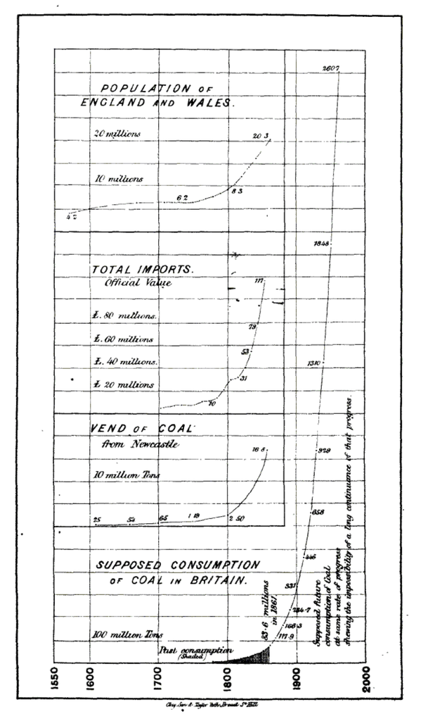

#### Jevons’ paradox (rebound effect)

An efficiency gain lowers the effective cost of using a resource, which increases demand for it, so total consumption can stay flat or rise rather than fall. Per-unit greening does not guarantee an aggregate saving.

#### Case: the “green” model upgrade

A large AI provider announces a new model that uses one tenth of the energy per query and markets it as a climate win. Six months later the company’s total electricity bill has *risen*. The engineering claim was true, so what happened?

*Solution*. This is **Jevons’ paradox** in miniature. The per-query efficiency gain was real, but it lowered the cost and latency of using the model, which the company then leveraged: the cheaper model was embedded in more products, offered free to more users, and invoked for longer, more complex tasks such as multi-step “agentic” workflows that fire many queries per request. If demand grows more than tenfold in response to a tenfold efficiency gain, total consumption rises despite the greener per-query number, which is what the rebound slider in the widget above demonstrates. The ethical lesson is that efficiency framed as a *marketing* claim can obscure the aggregate trajectory. Genuine sustainability requires attention to *total* demand, through transparency about footprints (as Li et al. urge), procurement of clean energy, and, more radically, the post-growth question of whether some uses are worth their planetary cost at all. Efficiency without a cap is not a climate strategy.

### 2.5 Whose transformation, at whose cost?

Both halves of this unit end at the same place. The transformation of work and the ecological footprint of AI are not separate topics but two faces of one question about *distribution*: who reaps the productivity gains, and who bears the costs, whether as deskilled labour, as invisible content moderation in the global South, or as water and carbon drawn from a shared and finite biosphere. The payroll evidence adds a generational and a gendered edge to that list, since the rungs thinning first are the entry rungs of the career ladder, and the occupations most exposed are the ones women hold at every age. The critiques of modernization, alienation, postcolonial extraction and ecological limits, turn out to describe the AI wave with uncomfortable precision. None of this settles whether AI is a transformation worth having; it clarifies the terms on which that judgement must be made. Those terms are exactly what the next unit takes up, turning from diagnosis to response by surveying how the major international organizations have tried to formulate ethical guidelines for AI.

## 3 References

### 3.1 Literature

- Acemoglu, D. & Restrepo, P. (2022): Tasks, Automation, and the Rise in U.S. Wage Inequality. *Econometrica* 90 (5), pp. 1973-2016. https://doi.org/10.3982/ECTA19815
- Bankins, S. & Formosa, P. (2023): The Ethical Implications of Artificial Intelligence (AI) for Meaningful Work. *Journal of Business Ethics* 185 (4), pp. 725-740. https://doi.org/10.1007/s10551-023-05339-7
- Baudchon, H. & Huynh, L. (2025): *Productivity, Growth and Employment in the AI Era: A Literature Review*. BNP Paribas Economic Research / BCG Henderson Institute, 9 September 2025.
- Brynjolfsson, E., Chandar, B. & Chen, R. (2026): *Canaries in the Coal Mine? Six Facts about the Recent Employment Effects of Artificial Intelligence*. Stanford Digital Economy Lab, August 2026 (updating the August 2025 version; ADP payroll data through June 2026). Underlying series updated monthly via the public AI Economic Indicators: https://digitaleconomy.stanford.edu/project/indicators/canaries-dashboard/
- Gmyrek, P., Berg, J. & Bescond, D. (2023): *Generative AI and Jobs: A Global Analysis of Potential Effects on Job Quantity and Quality*. ILO Working Paper 96. International Labour Organization, Geneva. https://doi.org/10.54394/FHEM8239
- Jevons, W. S. (1866): *The Coal Question: An Inquiry Concerning the Progress of the Nation, and the Probable Exhaustion of Our Coal-Mines*, 2nd ed. Macmillan, London.
- Li, P., Yang, J., Islam, M. A. & Ren, S. (2023): *Making AI Less “Thirsty”: Uncovering and Addressing the Secret Water Footprint of AI Models*. arXiv:2304.03271. https://arxiv.org/abs/2304.03271
- Patterson, D., Gonzalez, J., Le, Q., Liang, C., Munguia, L.-M., Rothchild, D., So, D., Texier, M. & Dean, J. (2021): *Carbon Emissions and Large Neural Network Training*. arXiv:2104.10350. https://arxiv.org/abs/2104.10350
- Rosa, H. (2005): *Beschleunigung. Die Veränderung der Zeitstrukturen in der Moderne*. Suhrkamp, Frankfurt am Main.

### 3.2 Norms & Standards

- United Nations (2015): *Transforming Our World: The 2030 Agenda for Sustainable Development* (Resolution A/RES/70/1), establishing the 17 Sustainable Development Goals. https://sdgs.un.org/2030agenda